# TP FINAL ‘CURSO R’ (ASET, 2024) - LUIS MATÍAS CARO

Docentes: Facundo Lastra - Guido Weksler

## **I. INTRODUCCIÓN**

El presente trabajo tiene por objeto hacer un tratamiento y análisis descriptivo del fénomeno de “precariedad laboral” o “trabajo precario”, como ejercicio comparativo entre la población nacional-argentina y extranjera-inmigrante, en relación a la base de datos de la “Encuesta Permanente de Hogares” (EPH), tercer trimestre año 2024, del Instituto Nacional de Estadística y Censos (INDEC), Argentina.

La base de datos y el documento de libro de códigos se encuentran en el siguiente link:

[INDEC, 2024 (Argentina)](https://www.indec.gob.ar/indec/web/Institucional-Indec-BasesDeDatos)

La EPH contempla un instrumento y base de datos de relevamiento socioeconómico de 31 aglomerados urbanos del país. En su muestra, se registran todas las zonas regionales del país, capitales provinciales y sus aglomerados urbanos. Su aplicación es trimestral, publicandose los resultados de estimaciones en cuatro temporadas durante el año, entregandose evidencia de indicadores sociales del país referentes a pobreza, nivel educacional, mercado de trabajo y otros.

## **II. DATOS DESCRIPTIVOS**

## 1. Composición de la muestra, por sexo y nacionalidad.

TABLA 1. Población según sexo

| Varones | Mujeres | Total |
| --- | --- | --- |
| 14.471.801 | 15.248.344 | 29.720.145 |

TABLA 2. Población según nacionalidad

| Argentino | Extranjero | Total |
| --- | --- | --- |
| 28.228.860 | 1.472.625 | 29.720.145 |

## 2. Población según rango etario

TABLA 3. Población según rango etario

| Menores 0-14 años | Adolescente 15-17 años | Adulto joven 18-29 años | Adulto 30-64 años | Adulto mayor 64+ años | Total |
| --- | --- | --- | --- | --- | --- |
| 6.688.406 | 1.347.578 | 5.310.917 | 12.688.249 | 3.684.995 | 29.720.145 |

## 3. Población según nivel educativo

TABLA 4.Población según nivel educativo

| Secundario incompleto o menos | Secundario Completo | Superior Completo | Total |
| --- | --- | --- | --- |
| 15.551.639 | 9.628.912 | 4.539.594 | 29.720.145 |

## 4. Descriptivos de precariedad laboral

En la presente propuesta, la “precariedad laboral” se comprende en el marco de la “población ocupada” (ESTADO = 1). Según la literatura, se consideran “trabajadores precarios” bajo condiciones laborales endebles sin descuento jubilatorio, con caracteristicas de no-registración (informalidad), de inestabilidad (empleos de tiempo determinado, plan de empleo, pasantía, periodo de prueba), trabajadores familiares sin remuneración, y asalariados del sector formal e informal de manera indistinta del tamaño de establecimiento (empresa).

TABLA 5. Cantidad de trabajadores ocupados en condición de precariedad

| Trabajadores precarios | Trabajadores no-precarios | Población ocupada |
| --- | --- | --- |
| 4.561.174 | 8.806.866 | 13.368.040 |

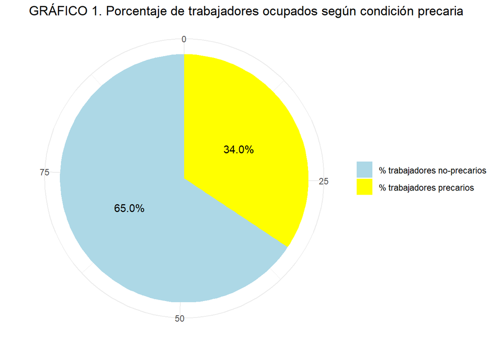

## 4. a) Precariedad según sexo

TABLA 6. Cantidad de trabajadores ocupados según condición precaria, por sexo

| Sexo | Trabajadores precarios | Trabajadores no-precarios | Población ocupada |
| --- | --- | --- | --- |
| Hombre | 2.423.364 | 5.054.719 | 7.478.083 |
| Mujer | 2.137.810 | 3.752.147 | 5.889.957 |

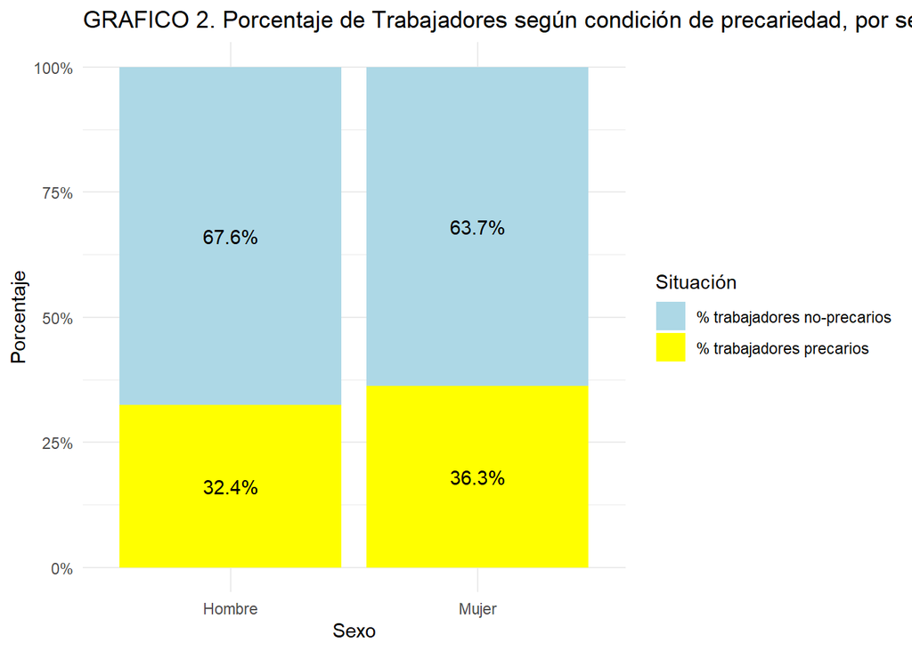

## 4. b) Precariedad según nacionalidad

TABLA 7. Cantidad de trabajadores ocupados según condición precaria, por nacionalidad

| nacionalidad | Trabajadores precarios | Trabajadores no-precarios | Población ocupada |
| --- | --- | --- | --- |
| Argentino | 4.273.588 | 8.273.058 | 12.546.646 |
| Extranjero | 287.367 | 525.612 | 812.979 |

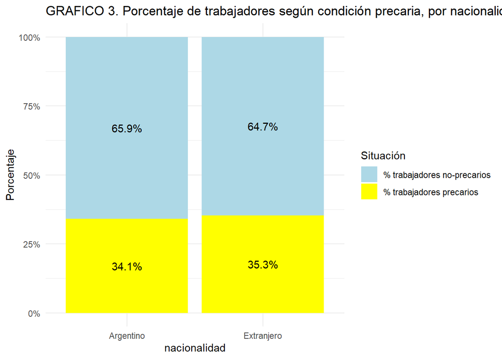

## 4. c) Precariedad según rango etario

TABLA 8. Cantidad de trabajadores ocupados según condición precaria, por rango etario

| Rango etario | Trabajadores precarios | Trabajadores no-precarios | Población ocupada |
| --- | --- | --- | --- |
| Menores 0-14 años | 7.870 | 173 | 8.043 |
| Adolescente 15-17 años | 26.872 | 17.473 | 44.345 |
| Adulto joven 18-29 años | 1.522.156 | 1.375.468 | 2.897.624 |
| Adulto 30-64 años | 2.865.825 | 6.964.613 | 9.830.438 |
| Adulto mayor 64+ años | 138.451 | 449.139 | 587.590 |

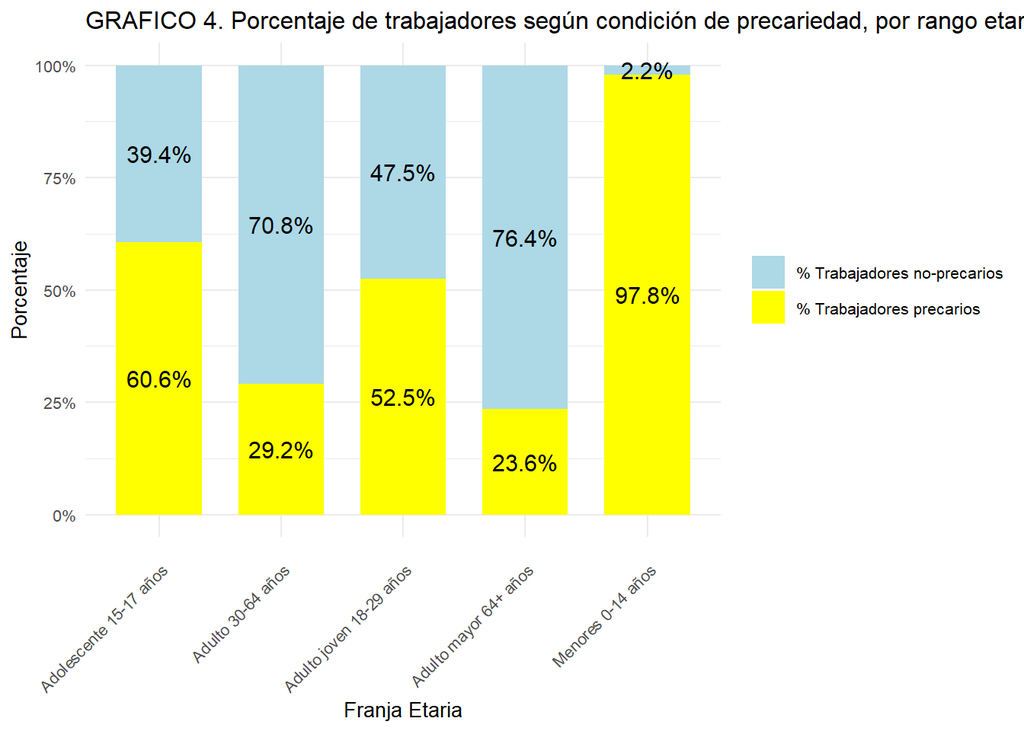

## 4. d) Precariedad según nivel educacional

TABLA 8. Cantidad de trabajadores ocupados según condición de precariedad, por nivel educacional

| Nivel Educativo | Trabajadores precarios | Trabajadores no-precarios | Población ocupada |
| --- | --- | --- | --- |
| Secundario incompleto o menos | 1.694.293 | 2.098.028 | 3.792.321 |
| Secundario Completo | 2.126.578 | 3.901.072 | 6.027.650 |
| Superior Completo | 740.303 | 2.807.766 | 3.548.069 |

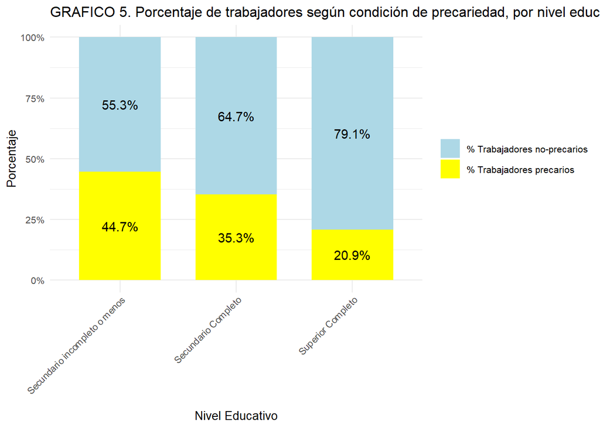